# 1) Preprocessing and QC filtering

September 17, 2026

This script performs preprocessing and quality control (QC) filtering of single-cell RNA sequencing (scRNA-seq) data generated using conventional 10x Genomics, 10x Genomics FLEX v1 and v2 (Apex), and Parse Biosciences Mini and Midi kits. The R package CRMetrics (https://github.com/khodosevichlab/CRMetrics) is utilized for QC in this script.

QC filtering involves iterative adjustments to determine the optimal thresholds for filtering **depth** (unique molecular identifiers [UMIs] per cell), **mitochondrial (mito) fraction** (percentage of mitochondrial genes per cell), and **doublets** (two or more cells of different cell types barcoded as one cell). Final clustering is not conducted in this script, it is addressed in a subsequent script, “Clustering_and_annotation”.

If ambient RNA filtering is applied, it is performed first, followed by filtering based on depth, mitochondrial fraction, and doublets.

Due to its computational intensity, ambient RNA filtering is not part of the standard analysis pipeline but is performed upon specific user request.

**Note for 10x Flex:** The following genes are excluded from the human and mouse probe sets:

```
TCR joining and variable regions
IG joining and variable regions
Ribosomal proteins
Mitochondrial ribosomal proteins
Read-through genes
KIR and HLA genes (due to their inherent allelic diversity)
Non-coding RNA
```

# 1 QC of raw seq data

Inspect sequencing quality by running fastQC and multiQC on fastq data. Links to multiQC report can be provided.

## 1.1 Parse

**Read 1: cDNA Insert 64bp** - genomic DNA –> high sequence diversity - Generally high per-base quality - Slight dip at the start (first 4-5 cycles) (normal) - Slight decline near the end (normal) - usually many duplicated reads as we sequence fragments of the same transcripts from the same genes, so many reads are biologically duplicated (UMIs are not in R1)

**Read 2: Barcodes 1-3 58bp** - barcodes do not have the same nucleotide diversity as random cDNA –> lower Q scores - Per-base quality should stay mostly above Q20/above red zone (~99% accuracy) - quality dips at specific cycles into red zone = below Q20

**Index 1/2 (8 bp each)** - Very low diversity

**investigate further if** - Read 2 collapses below Q10 - There are strong dropouts in particular barcode segments - You see warnings in “Per tile quality” (indicating lane issues) - Adapter content is extremely high in R1 - Overrepresented sequences dominate R1 (should not happen in cDNA) - sharp peaks or overrepresented sequences in the GC content analysis could indicate potential contamination or biologically relevant sequences. While these occurrences might not always be problematic, it’s a good practice to investigate them further to determine if they align with experimental expectations.

## 1.2 10x Genomics

to be updated

# 2 Inspection of reports produced by count pipelines

First step in QC is to inspect the summary reports produced by cellranger (10x Genomics) and split-pipe (Parse Biosciences). Check if any warnings or errors are present and check shape of barcode-rank-plot (= knee plot). Those summary reports can be shared with the user.

In a **barcode rank plot**, barcodes are ordered based on the number of associated transcripts, which are plotted along a gradient using log-transformed axes. The inflection point—a key feature of the plot—represents the minimum transcript threshold. Barcodes above this threshold are considered to correspond to individual cells, while those below are interpreted as background or ambient RNA. This inflection point allows the pipelines to set a cell cutoff threshold, distinguishing real cells from noise in the data. A well-formed knee plot is an indication of a successful experiment. The clear inflection point, or “knee,” suggests that the cell preparation and sequencing process went smoothly. On the other hand, if the plot shows a smooth curve without a defined knee, it may indicate problems with the input sample, such as an excess of dead or damaged cells. This is a sign that the sample quality might have been compromised, and further investigation is needed

MultiQC can also be run on cellranger count outputs to get a sample metrics overview. Links to multiQC reports can be provided. MultiQC does not yet work on cellranger multi (FLEX) and Parse output.

# 3 Setup R libraries

```r
# loading locally adapted CRMetrics version for 10xFlex v2
devtools::load_all("/people/nrq364/CRMetrics_LW")
library(magrittr)
library(dplyr)
library(conos)
library(pagoda2)
library(qs2)
library(ggplot2)
```

# 4 Create CRMetrics object

In case of Parse data use data.path to “combined” folder, for 10x FLEX data.path to “per_sample_outs” folder. Metadata should at least contain “sample” and “group/condition” but can have more columns. Make sure there are no whitespaces after each row, it will introduce duplicated factor levels for condition for example!

```r
crm <- CRMetrics$new(data.path = "/data/counts/[project_name]/",
                     metadata = "path_to_metadata.csv",
                     n.cores = 60, technology="10x")
```

```r
crm$metadata
```

| sample | condition |
| --- | --- |
| control_1 | control |
| control_2 | control |
| control_4 | control |
| control_5 | control |
| control_6 | control |
| control_7 | control |
| treated_1 | treated |
| treated_2 | treated |
| treated_3 | treated |
| treated_4 | treated |

[output cut: 2 more lines]

# 5 Check barcode rank plots

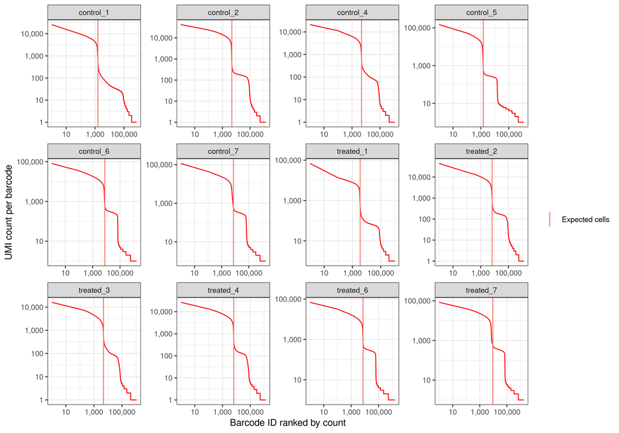

```r
crm$plotBarcodeRankPlot()
```

# 6 Basic metrics

Show available metrics to plot.

```r
crm$selectMetrics()
```

| no | metrics |
| --- | --- |
| 1 | estimated number of cells |
| 2 | mean reads per cell |
| 3 | median genes per cell |
| 4 | number of reads |
| 5 | valid barcodes |
| 6 | sequencing saturation |
| 7 | q30 bases in barcode |
| 8 | q30 bases in rna read |
| 9 | q30 bases in umi |
| 10 | reads mapped to genome |

[output cut: 9 more lines]

## 6.1 Plot selected metrics per sample

From list of metrics above, you can choose which barplots you would like to receive if the default ones are not sufficient. Default metrics: estimated number of cells, mean reads per cell, sequencing saturation, median genes per cell, total genes detected, median UMI counts per cell

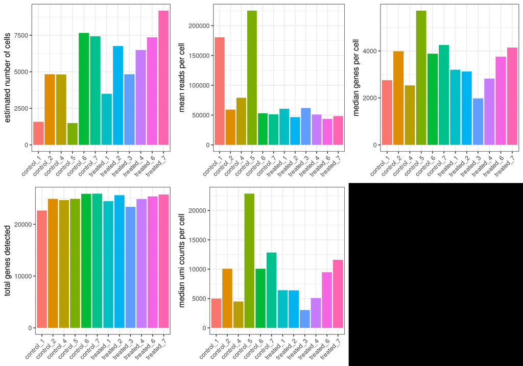

```r
metrics.to.plot <- crm$selectMetrics(ids = c(1:3,18,19))
crm$plotSummaryMetrics( comp.group = "sample", metrics = metrics.to.plot,plot.geom ="bar")
```

## 6.2 Plot selected metrics per condition

We can do the same, but set the comparison group to condition. This will add statistics to the plots. Additional, we can add a second comparison group (that is available in the metadata) for coloring. Default metrics plotted are the same as above. User can select more from the list.

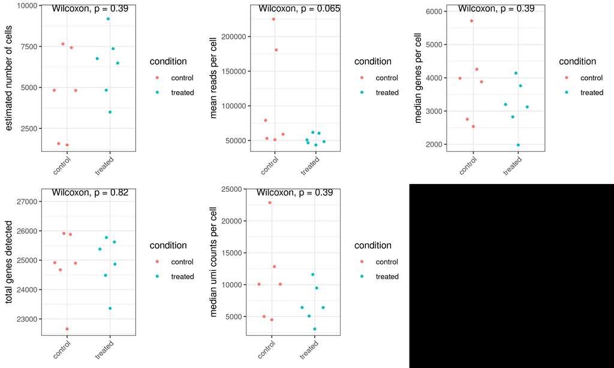

```r
crm$plotSummaryMetrics(comp.group = "condition",
                       metrics = metrics.to.plot,
                       plot.geom = "point",
                       stat.test = "non-parametric") #second.comp.group= "sex"
```

We can observe that “mean reads per cell” are almost significantly higher in controls compared to treated.

## 6.3 Add and plot detailed metrices

```r
crm$addCms(add.metadata=F)
crm$addDetailedMetrics(n.cores = 30)
```

get total number of sequenced nuclei

```r
sum(sapply(crm$cms, function(d) dim(d)[2]))
```

```
## [1] 65904
```

plot UMIs and genes per sample before filtering, horizontal lines indicate the median values for all samples

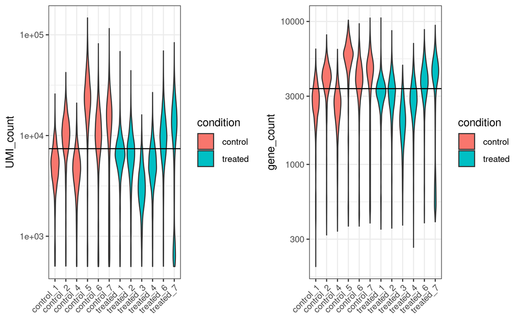

```r
crm$plotDetailedMetrics(comp.group = "condition",
                        metrics = c("UMI_count",  "gene_count"),
                        plot.geom = "violin")
```

Generate a data frame with the metrics.

```r
metrics <- crm$summary.metrics
metrics %<>% as.data.frame()
metrics
```

| sample | metric | value |
| --- | --- | --- |
| control_1 | estimated number of cells | 1.574000e+03 |
| control_1 | mean reads per cell | 1.806140e+05 |
| control_1 | median genes per cell | 2.752000e+03 |
| control_1 | number of reads | 2.842866e+08 |
| control_1 | valid barcodes | 9.540000e-01 |
| control_1 | sequencing saturation | 9.030000e-01 |
| control_1 | q30 bases in barcode | 9.640000e-01 |
| control_1 | q30 bases in rna read | 9.370000e-01 |
| control_1 | q30 bases in umi | 9.620000e-01 |
| control_1 | reads mapped to genome | 9.020000e-01 |

[output cut: 218 more lines]

Get median genes per cell across all samples before filtering (in case of Parse: “hg38_median_genes_per_cell”).

```r
median(metrics[metrics$metric=="median genes per cell",]$value)
```

```
## [1] 3478
```

Get median UMIs per cell across all samples before filtering (in case of Parse: “hg38_median_tscp_per_cell”).

```r
median(metrics[metrics$metric=="median umi counts per cell",]$value)
```

```
## [1] 7945
```

# 7 Embed cells using conos

We are embedding cells in a UMAP graph to visualize filtered cells in the embedding (they often cluster together or form bridges between clusters). To plot the cells in an embedding, we need to preprocess the raw count matrices with pagoda2 (seurat is also possible).

```r
crm$doPreprocessing() #min.transcripts.per.cell = 100
```

Create embedding using conos. This functions executes the functions Conos$new(cms, n.cores = n.cores), buildGraph(), findCommunities(), embedGraph(method = “UMAP”), with default settings, which can be adjusted.

```r
crm$createEmbedding()
```

Plot the embedding. This is before filtering, so we are not yet interested in the clusters, those are refined in the next script.

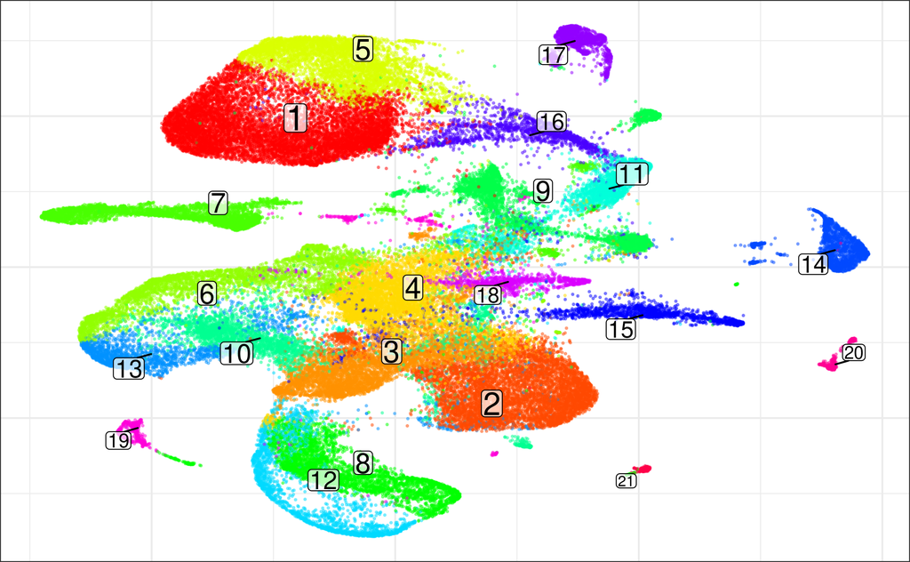

```r
crm$plotEmbedding() # cells with UMI count < 100 not included as filtered out in "doPreprocessing"
```

# 8 Filtering out low quality cells

## 8.1 Cell depth (= UMI counts per cell)

Plotting cell depth in a density histogram. - The area under the curve sums to 1 for each distribution. - The y-axis shows a probability density — i.e., how common a given depth is relative to that sample’s total. - This allows you to compare shapes of distributions directly, even if the number of cells per sample differs.

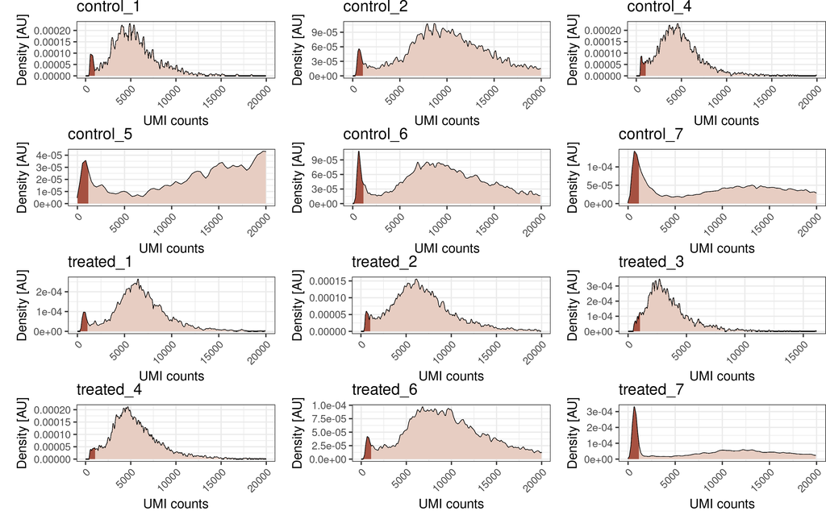

```r
crm$plotDepth()
```

If the depth distribution varies between samples, we can use sample-specific cutoffs.

```r
depth_cutoff_vec <- c(1e3, 1e3, 500, 1e3, 1e3, 500, 1e3, 1e3, 1e3, 1e3, 1e3, 500) %>%
  setNames(crm$detailed.metrics$sample %>%
             unique() %>%
             sort())

depth_cutoff_vec
```

```
## control_1 control_2 control_4 control_5 control_6 control_7 treated_1 treated_2 treated_3 treated_4 treated_6 treated_7
##      1000      1000       500      1000      1000       500      1000      1000      1000      1000      1000       500
```

Plot sample specific cutoff in histogram and embedding.

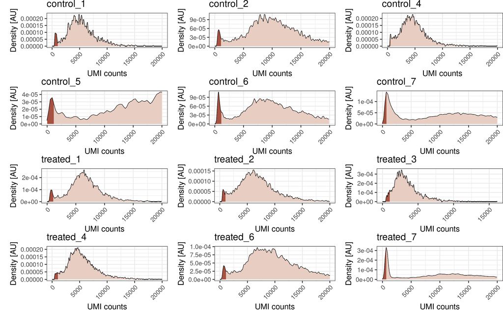

```r
crm$plotDepth(cutoff = depth_cutoff_vec)
```

Plotting raw cell depth in a hsitogram.

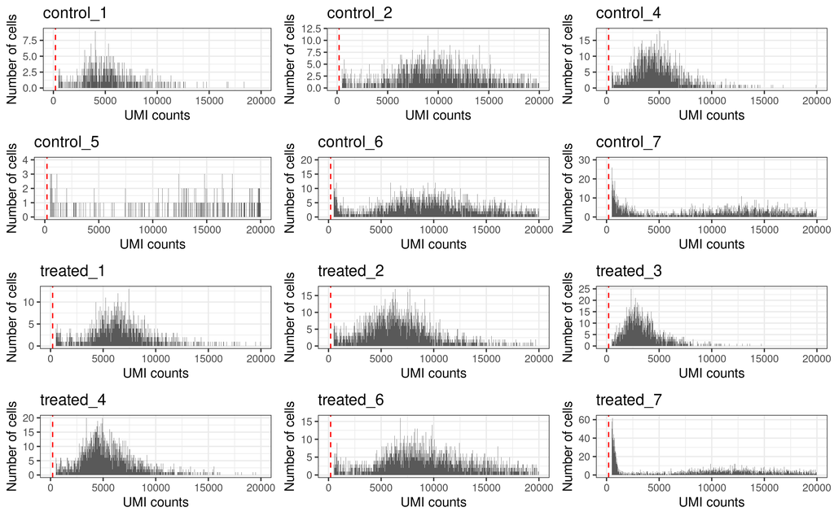

```r
crm$plotRawDepth(cutoff = 200, xupper = 2e4, binwidth=10)
```

Plotting continuous depth values in the embedding.

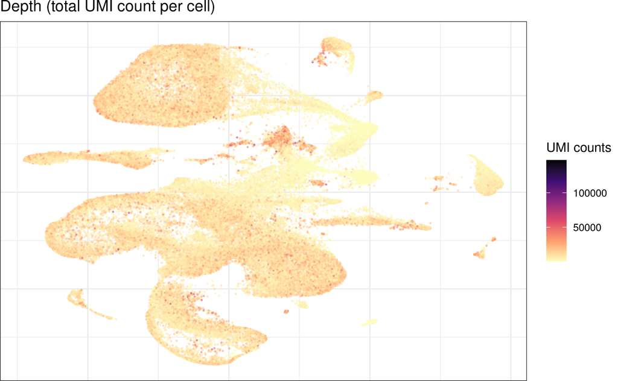

```r
crm$plotEmbedding(depth = TRUE)
```

Plotting cells with low depth in the embedding.

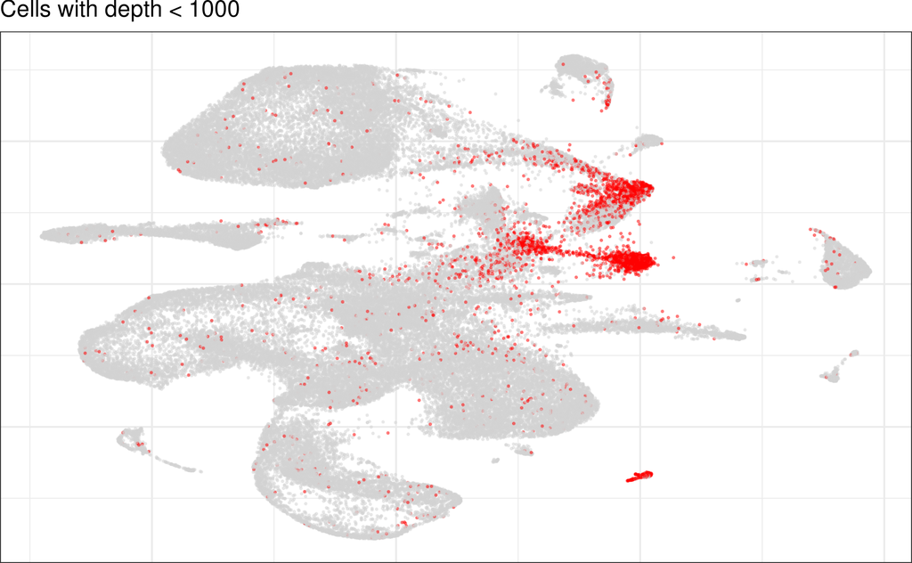

```r
crm$plotEmbedding(depth = TRUE,
             depth.cutoff = 1000)
```

Plot the sample-specific depth cut-offs in the embedding.

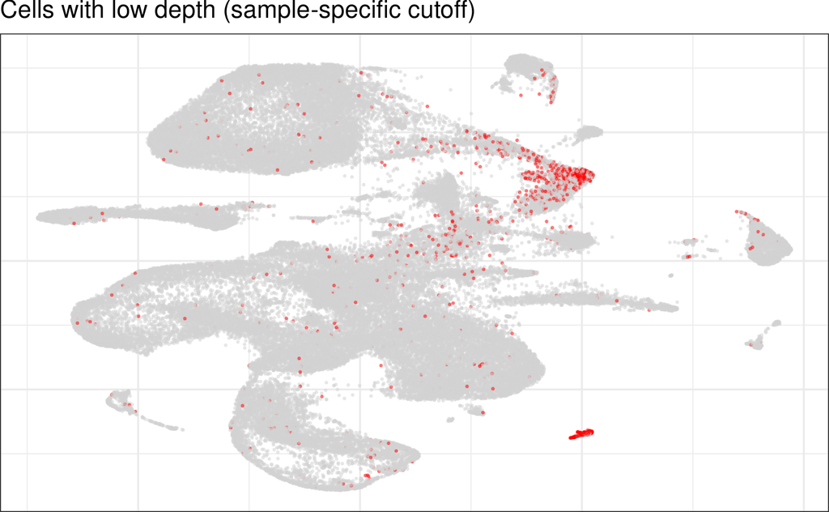

```r
crm$plotEmbedding(depth = TRUE,
             depth.cutoff = depth_cutoff_vec)
```

We expect the low depth cells to form their own clusters, or to be located at the edge of clusters, or form “bridges” between clusters.

We can also plot an upper depth cutoff, which is especially needed in Parse datasets. In Parse datasets we often observe cells with very high UMI counts likely being clumps of cells. But here in this dataset we do not need to filter based on high UMI counts.

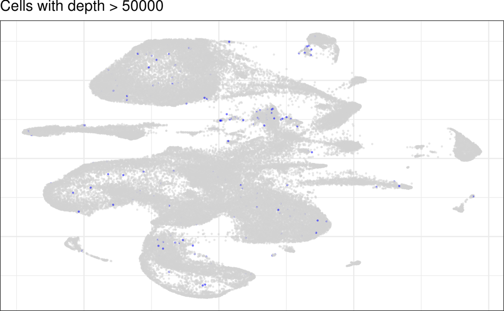

```r
crm$plotEmbedding(depth = TRUE,
             depth.cutoff.upper = 50000)
```

## 8.2 Mitochondrial gene fraction

Investigate the mitochondrial gene fraction in the cells. Plot embedding with continuous values.

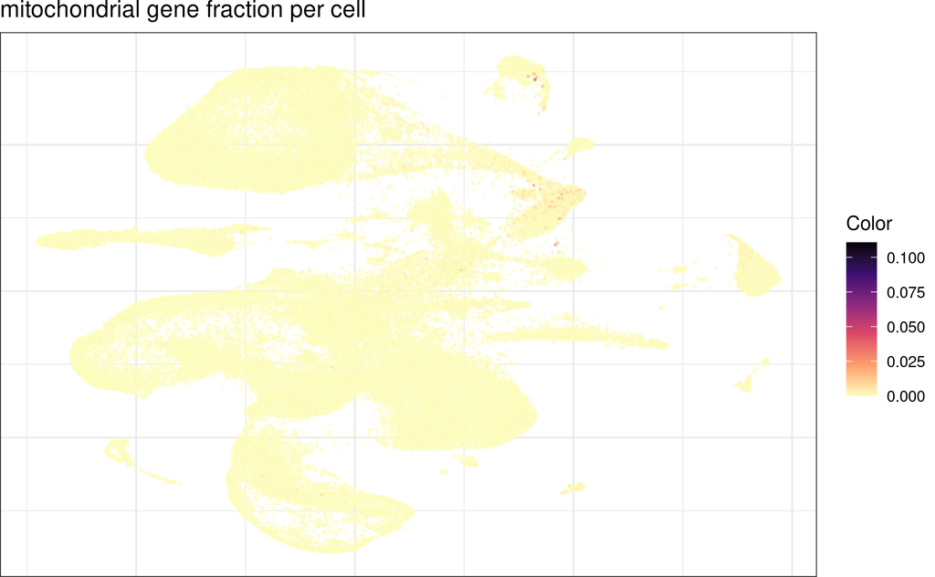

```r
crm$plotEmbedding(mito.frac = TRUE,  species = "mouse")
```

A high mito fraction indicates dying or raptured cells. The example dataset has a very low expression of mitochondrial genes. Usual cutoff is 5% (in mouse tissue) or higher (in postmortem human samples).

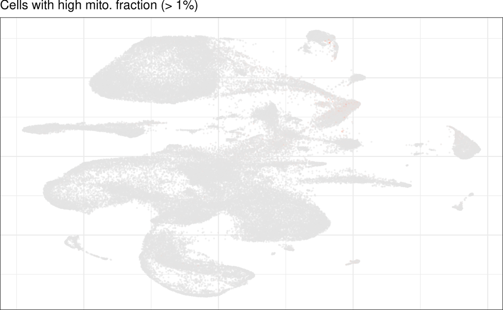

```r
crm$plotEmbedding(mito.frac = TRUE,
             mito.cutoff = 0.01,
             species = "mouse")
```

Similar as for depth, we can plot the distribution of the mitochondrial fraction per sample and include sample-wise cutoffs (not shown here as the example dataset has only a very low expression of mitochondrial genes).

```r
crm$plotMitoFraction(cutoff = 0.01)
```

## 8.3 Doublet detection

Doublet detection within CRMetrics is possible with the python packages `scrublet` or `DoubletDetection` as well as R package `scDblFinder`. `Scrublet` is the default method, which is fast. `DoubletDetection` is significantly slower, but performs better according to this review (https://www.sciencedirect.com/science/article/pii/S2405471220304592). Which one to choose depends on the dataset and technology used. Usually we use `scrublet` for conventinal 10x Genomics datasets and `scDblFinder` for Parse datasets.

Here we use `scrublet`. `Scrublet` is installed into a virtual environment. `Scrublet` is run from within R.

```r
# run as background job to prevent R from crashing
crm$detectDoublets(env = "scrublet",
                   conda.path = "/opt/software/miniconda/4.12.0/condabin/conda",
                   method = "scrublet")
# Detected 2494 possible doublets out of 65904 cells.
```

Inspect scrublet output

```r
crm$doublets$scrublet$output
```

```
## $control_1
## [1] "Preprocessing...\nSimulating doublets...\nEmbedding transcriptomes using PCA...\nCalculating doublet scores...\nAutomatically set threshold at doublet score = 0.56\nDetected doublet rate = 0.3%\nEstimated detectable doublet fraction = 23.0%\nOverall doublet rate:\n\tExpected   = 10.0%\n\tEst…
##
## $control_2
## [1] "Preprocessing...\nSimulating doublets...\nEmbedding transcriptomes using PCA...\nCalculating doublet scores...\nAutomatically set threshold at doublet score = 0.38\nDetected doublet rate = 2.2%\nEstimated detectable doublet fraction = 37.8%\nOverall doublet rate:\n\tExpected   = 10.0%\n\tEst…
##
## $control_4
## [1] "Preprocessing...\nSimulating doublets...\nEmbedding transcriptomes using PCA...\nCalculating doublet scores...\nAutomatically set threshold at doublet score = 0.34\nDetected doublet rate = 2.9%\nEstimated detectable doublet fraction = 33.7%\nOverall doublet rate:\n\tExpected   = 10.0%\n\tEst…
##
## $control_5
## [1] "Preprocessing...\nSimulating doublets...\nEmbedding transcriptomes using PCA...\nCalculating doublet scores...\nAutomatically set threshold at doublet score = 0.41\nDetected doublet rate = 2.4%\nEstimated detectable doublet fraction = 22.4%\nOverall doublet rate:\n\tExpected   = 10.0%\n\tEst…
##
## $control_6
## [1] "Preprocessing...\nSimulating doublets...\nEmbedding transcriptomes using PCA...\nCalculating doublet scores...\nAutomatically set threshold at doublet score = 0.27\nDetected doublet rate = 6.2%\nEstimated detectable doublet fraction = 41.0%\nOverall doublet rate:\n\tExpected   = 10.0%\n\tEst…
##
## $control_7
## [1] "Preprocessing...\nSimulating doublets...\nEmbedding transcriptomes using PCA...\nCalculating doublet scores...\nAutomatically set threshold at doublet score = 0.27\nDetected doublet rate = 4.3%\nEstimated detectable doublet fraction = 28.8%\nOverall doublet rate:\n\tExpected   = 10.0%\n\tEst…
##
## $treated_1
## [1] "Preprocessing...\nSimulating doublets...\nEmbedding transcriptomes using PCA...\nCalculating doublet scores...\nAutomatically set threshold at doublet score = 0.36\nDetected doublet rate = 2.5%\nEstimated detectable doublet fraction = 39.0%\nOverall doublet rate:\n\tExpected   = 10.0%\n\tEst…
##
## $treated_2
## [1] "Preprocessing...\nSimulating doublets...\nEmbedding transcriptomes using PCA...\nCalculating doublet scores...\nAutomatically set threshold at doublet score = 0.34\nDetected doublet rate = 3.3%\nEstimated detectable doublet fraction = 38.6%\nOverall doublet rate:\n\tExpected   = 10.0%\n\tEst…
##
## $treated_3
## [1] "Preprocessing...\nSimulating doublets...\nEmbedding transcriptomes using PCA...\nCalculating doublet scores...\nAutomatically set threshold at doublet score = 0.73\nDetected doublet rate = 0.2%\nEstimated detectable doublet fraction = 1.3%\nOverall doublet rate:\n\tExpected   = 10.0%\n\tEsti…
##
## $treated_4
## [1] "Preprocessing...\nSimulating doublets...\nEmbedding transcriptomes using PCA...\nCalculating doublet scores...\nAutomatically set threshold at doublet score = 0.32\nDetected doublet rate = 3.8%\nEstimated detectable doublet fraction = 34.9%\nOverall doublet rate:\n\tExpected   = 10.0%\n\tEst…
##
## $treated_6
## [1] "Preprocessing...\nSimulating doublets...\nEmbedding transcriptomes using PCA...\nCalculating doublet scores...\nAutomatically set threshold at doublet score = 0.25\nDetected doublet rate = 7.6%\nEstimated detectable doublet fraction = 47.7%\nOverall doublet rate:\n\tExpected   = 10.0%\n\tEst…
##
## $treated_7
## [1] "Preprocessing...\nSimulating doublets...\nEmbedding transcriptomes using PCA...\nCalculating doublet scores...\nAutomatically set threshold at doublet score = 0.29\nDetected doublet rate = 3.1%\nEstimated detectable doublet fraction = 20.7%\nOverall doublet rate:\n\tExpected   = 10.0%\n\tEst…
```

Check doublet detection results in barplot:

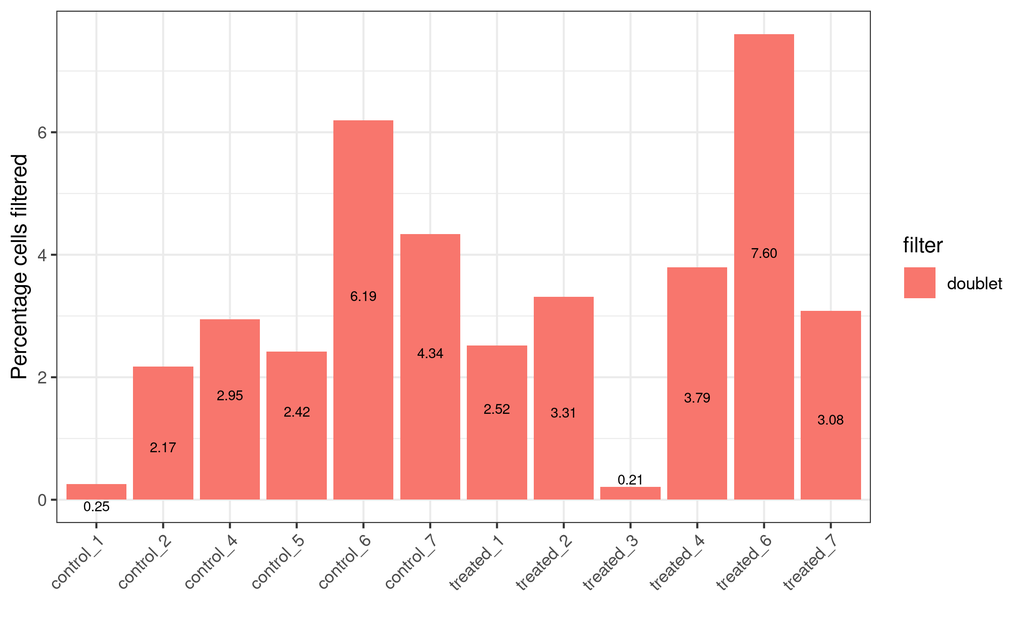

```r
crm$plotFilteredCells(type = "bar", doublet.method = "scrublet")
```

Plot estimated doublet scores in embedding.

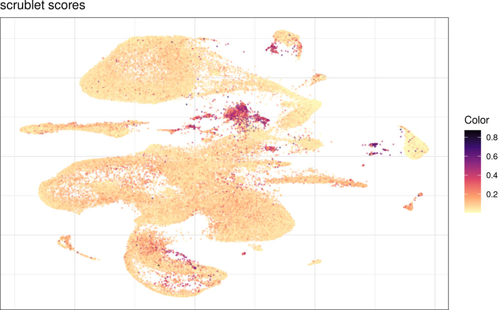

```r
crm$plotEmbedding(doublet.method= "scrublet", doublet.scores = T)
```

Plot the estimated doublets in the embedding.

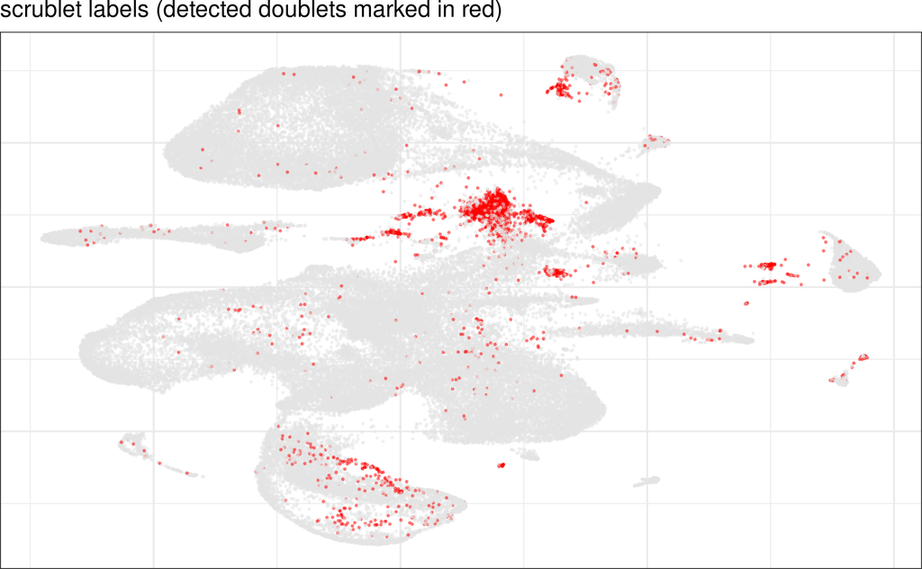

```r
crm$plotEmbedding(doublet.method = "scrublet")
```

## 8.4 Plot filtered cells

Plot all cells to be filtered on the embedding.

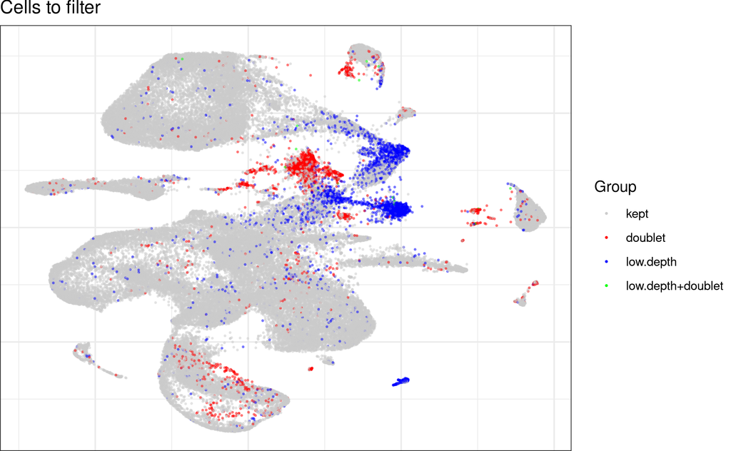

```r
crm$plotFilteredCells(type = "embedding",
                      depth = TRUE,
                      depth.cutoff = 1000,
                      doublet.method = "scrublet",
                      mito.frac = FALSE,
                      species = "mouse")
#ggsave("img/1_preprocessing/fig17.png")
```

Plot the cells to be filtered per sample in a bar plot where combination means a cell that has at least two filter labels, e.g. doublet and depth.

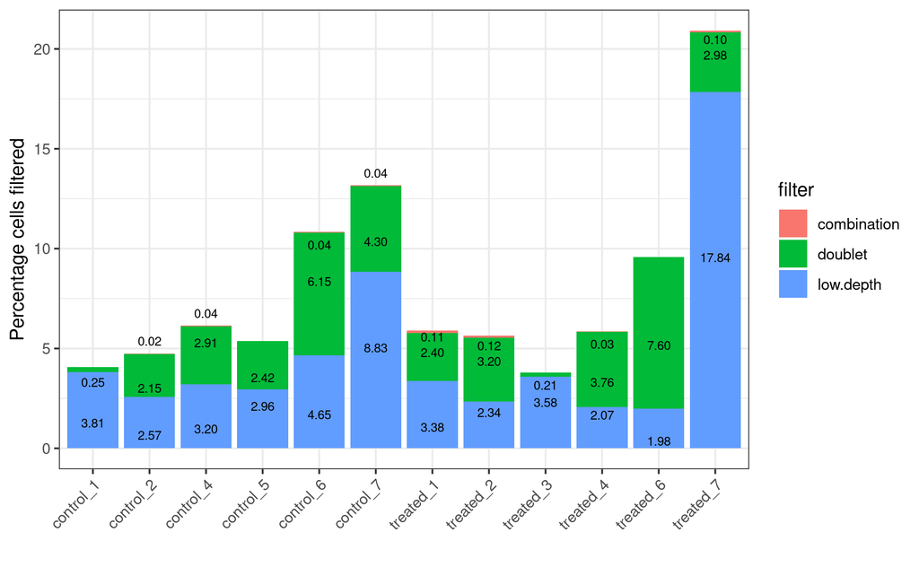

```r
crm$plotFilteredCells(type = "bar",
                      depth = TRUE,
                      depth.cutoff = 1000,
                      doublet.method = "scrublet",
                      mito.frac = FALSE,
                      species = "mouse")
#ggsave("img/1_preprocessing/fig18.png")
```

# 9 Filter and save count matrices

Finally, filter the count matrices to be used in downstream applications. If cellbender should be used then count matrices need to be added after cellbender and then all subsequent filtering is done.

```r
crm$filterCms(depth.cutoff = 1000,
              mito.cutoff = NULL,
              doublet.method = "scrublet",
              samples.to.exclude = NULL,
              species = "mouse",
              verbose = TRUE)
#Removing 6255 of 65904 cells (9.49%)
```

```r
qs_save(crm, "crm.qs2", nthreads = 30)
```

The filtered list of count matrices is stored in $cms.filtered which can be saved on disk.

```r
qs_save(crm$cms.filtered, "cms_filtered[_cellbender].qs2",
      nthreads = 10)
```

# 10 Optional: remove ambient RNA

We usually use cellbender, SoupX is also included in CRMetrics, but for now only works with conventional 10x data. Ambient RNA removal should be performed before filtering, it changes the number of called cells and their gene counts.

In the old cellbender version (before 0.3.0) we needed to specify expected number of cells and total droplets included. In case of Parse data, the following function creates the input files for cellbender from the Parse output.

```r
crm$prepareCellbender()
```

The following function prepares and saves the cellbender script. To only select specific samples, use the samples parameter. total.droplets and expected.cells are not needed anymore in cellbender v0.3.0, but can still be specified if needed.

```r
crm$saveCellbenderScript(file = "cellbender_script.sh",
                         fpr = 0.01,
                         epochs = 150,
                         use.gpu = TRUE)
```

We can run this script in the terminal (screen session). Here, we activate the environment: conda activate cellbender_v0.3.0 and we run the bash script: sh cellbender_script.sh.

## 10.1 Plot cellbender cell numbers

Plot the changes in cell numbers following CellBender estimations.

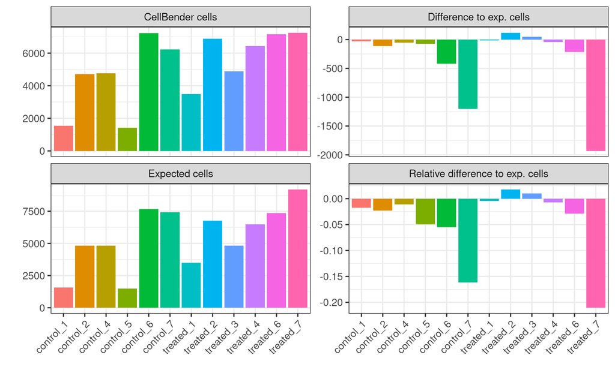

```r
crm$plotCbCells()
#ggsave("img/1_preprocessing/fig19.png")
```

## 10.2 Plot the CellBender training results.

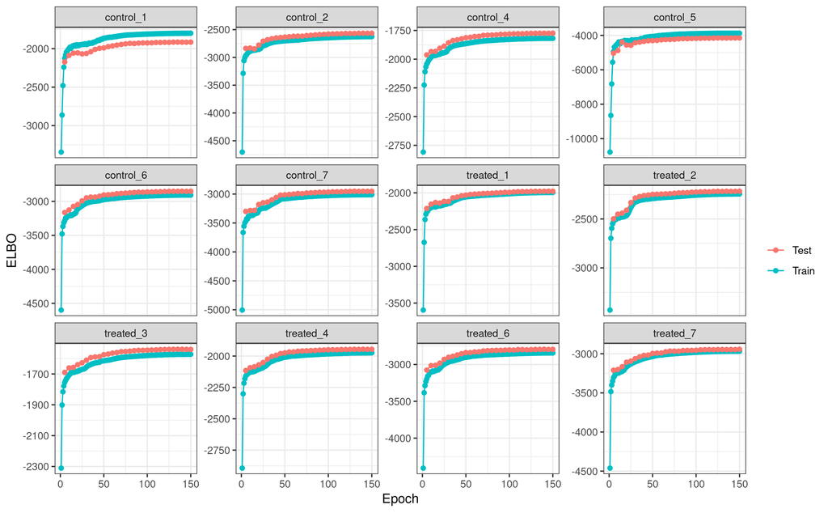

```r
crm$plotCbTraining()
#ggsave("img/1_preprocessing/fig20.png")
```

## 10.3 Plot the cell probabilities.

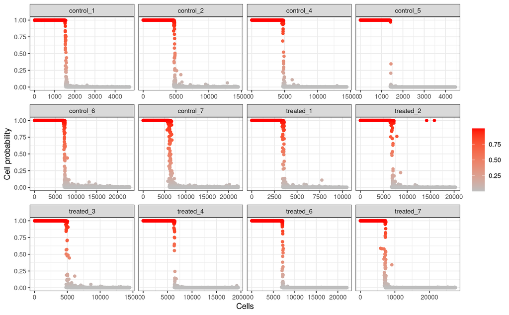

```r
crm$plotCbCellProbs()
#ggsave("img/1_preprocessing/fig21.png")
```

## 10.4 Plot the identified ambient genes per sample.

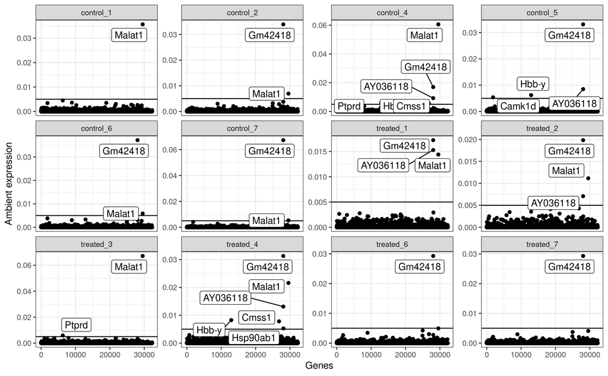

```r
crm$plotCbAmbExp(cutoff = 0.005)
#ggsave("img/1_preprocessing/fig22.png")
```

## 10.5 Plot proportion of samples expressing ambient genes

Lastly, plot the proportion of samples expressing ambient genes. MALAT1 is identified as an ambient gene in almost all samples which is expected.

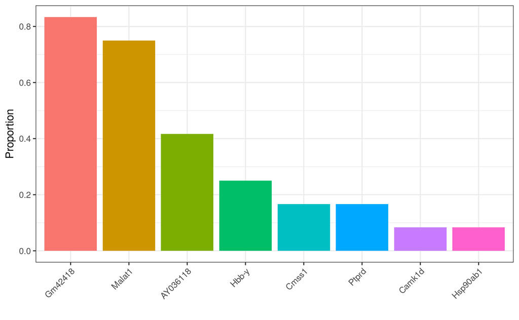

```r
crm$plotCbAmbGenes(cutoff = 0.005)
#ggsave("img/1_preprocessing/fig23.png")
```

## 10.6 Add cellbender filtered cms

Then, we can add the cellbender filtered cms to our object. Additionally, it is recommended to generate new summary metrics from the adjusted cms which can then be plotted.

```r
crm$cms <- NULL
crm$addCms(cellbender = T)
crm$addSummaryFromCms()
crm$detailed.metrics <- NULL
crm$addDetailedMetrics()
qs_save(crm, "crm_cellbender.qs2", nthreads=10)
```